# COMPSCIX 415.2 Homework 5/Midterm

Emerson Sosa

3/2/2019

```r
library(ggplot2)
library(tidyverse)
library(dplyr)
```

https://github.com/emers-glue/compscix-415-2-assignments

# 1 The tidyverse packages

*1. Can you name which package is associated with each task below?*

1. Plotting: For plotting, use the `ggplot2` package.
2. Data munging/wrangling: For data wrangling use the `dplyr` package.
3. Reshaping data: To reshape the data use the `tidyr` package.?
4. Importing/exporting data: For importing and exporting, use the `readr` package.

*2. Now can you name two functions that you’ve used from each package that you listed above for these tasks?*

1. Plotting: In conjunction with `ggplot2`, I have used the `geom_point()` and `geom_count()` for visualizing data.
2. Data munging/wrangling: The `filter()` function has been very useful for me and I have admired the power of the `summarise()` when used with the `group_by()` function.
3. Reshaping data: Understanding the usage of `gather()` and `spread()` will be essential when colloborating with others as it cannot be assumed that they will be using tidy data.
4. Importing/exporting data: To import data, use `read_csv()` to import and `write_csv()` to export as a csv. file.

# 2 R Basics

*1. Fix this code with the fewest number of changes possible so it works:*

I added quote marks around the tag to allow the exclamation point.

```r
('My_data.name___is.too00ooLong!' <- c( 1 , 2   , 3 ))
```

```
## [1] 1 2 3
```

*2. Fix this code so it works:*

To fix, I changed the case of the concatenation function to lower case and added a quote end mark to *it*.

```r
(my_string <- c('has', 'an', 'error', 'in', 'it'))
```

```
## [1] "has"   "an"    "error" "in"    "it"
```

*3. Look at the code below and comment on what happened to the values in the vector.*

R does not need quotes around numbers when making them a vector. When quotes are placed around them, R forces the exact input inside. For example, if a space is placed inside the quote marks, r will print that extra space as well. The same is not true when adding extra spaces to numbers without quotes around the number.

```r
my_vector <- c(1,2, '3', '4', 5)
my_vector
```

```
## [1] "1" "2" "3" "4" "5"
```

# 3 Data import/export

*1. Download the rail_trail.txt file from Canvas and successfully import it into R. Prove that it was imported successfully by including your import code and taking a glimpse of the result.*

```r
rail.trail.path <-
  'rail_trail.txt'
rail.trail.data <-
  read_delim('rail_trail.txt', delim = '|')
glimpse(rail.trail.data)
```

```
## Observations: 90
## Variables: 10
## $ hightemp   <dbl> 83, 73, 74, 95, 44, 69, 66, 66, 80, 79, 78, 65, 41, 5…
## $ lowtemp    <dbl> 50, 49, 52, 61, 52, 54, 39, 38, 55, 45, 55, 48, 49, 3…
## $ avgtemp    <dbl> 66.5, 61.0, 63.0, 78.0, 48.0, 61.5, 52.5, 52.0, 67.5,…
## $ spring     <dbl> 0, 0, 1, 0, 1, 1, 1, 1, 0, 0, 0, 1, 1, 0, 0, 1, 0, 1,…
## $ summer     <dbl> 1, 1, 0, 1, 0, 0, 0, 0, 1, 1, 1, 0, 0, 0, 0, 0, 1, 0,…
## $ fall       <dbl> 0, 0, 0, 0, 0, 0, 0, 0, 0, 0, 0, 0, 0, 1, 1, 0, 0, 0,…
## $ cloudcover <dbl> 7.6, 6.3, 7.5, 2.6, 10.0, 6.6, 2.4, 0.0, 3.8, 4.1, 8.…
## $ precip     <dbl> 0.00, 0.29, 0.32, 0.00, 0.14, 0.02, 0.00, 0.00, 0.00,…
## $ volume     <dbl> 501, 419, 397, 385, 200, 375, 417, 629, 533, 547, 432…
## $ weekday    <dbl> 1, 1, 1, 0, 1, 1, 1, 0, 0, 1, 1, 1, 1, 1, 1, 1, 0, 1,…
```

*2. Export the file into a comma-separated file and name it “rail_trail.csv”. Make sure you define the path correctly so that you know where it gets saved. Then reload the file. Include your export and import code and take another glimpse.*

```r
write_csv(rail.trail.data, 'rail.trail.csv')
rail.trail.csv <-
  read_csv('rail.trail.csv')
glimpse(rail.trail.csv)
```

```
## Observations: 90
## Variables: 10
## $ hightemp   <dbl> 83, 73, 74, 95, 44, 69, 66, 66, 80, 79, 78, 65, 41, 5…
## $ lowtemp    <dbl> 50, 49, 52, 61, 52, 54, 39, 38, 55, 45, 55, 48, 49, 3…
## $ avgtemp    <dbl> 66.5, 61.0, 63.0, 78.0, 48.0, 61.5, 52.5, 52.0, 67.5,…
## $ spring     <dbl> 0, 0, 1, 0, 1, 1, 1, 1, 0, 0, 0, 1, 1, 0, 0, 1, 0, 1,…
## $ summer     <dbl> 1, 1, 0, 1, 0, 0, 0, 0, 1, 1, 1, 0, 0, 0, 0, 0, 1, 0,…
## $ fall       <dbl> 0, 0, 0, 0, 0, 0, 0, 0, 0, 0, 0, 0, 0, 1, 1, 0, 0, 0,…
## $ cloudcover <dbl> 7.6, 6.3, 7.5, 2.6, 10.0, 6.6, 2.4, 0.0, 3.8, 4.1, 8.…
## $ precip     <dbl> 0.00, 0.29, 0.32, 0.00, 0.14, 0.02, 0.00, 0.00, 0.00,…
## $ volume     <dbl> 501, 419, 397, 385, 200, 375, 417, 629, 533, 547, 432…
## $ weekday    <dbl> 1, 1, 1, 0, 1, 1, 1, 0, 0, 1, 1, 1, 1, 1, 1, 1, 0, 1,…
```

# 4 Visualization

*1. Critique this graphic: give only three examples of what is wrong with this graphic.*

1. The choice in colors for the genders is a bit confusing. A byproduct of our patriarchal society lends colors like pink and purple being femenized, therefore it is a bit hard to detach the color from women. It would have been better to assign gender nuetral colors instead.
2. The tidy data does not adhere to the tidy data tenets because gender is clumped into two observations instead of being spread across the ages. It would have been better to spread the genders across age groups instead to see if there are distinctions there.
3. The presentations of the circles in this graphic also presents the problem of relative sizes. It is hard to distinguish the magnitude of each circle just by looking at the sizes and the inclusion of the value of each cirlce is really needed to sift through the sizes of each. It would have been better to do some sort of bar graph allowing the reader to quickly distinguish the difference in sizes by the height of each observation.

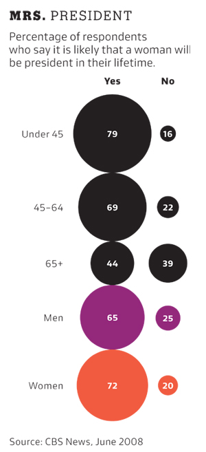

*2. Reproduce this graphic using the diamonds data set.*

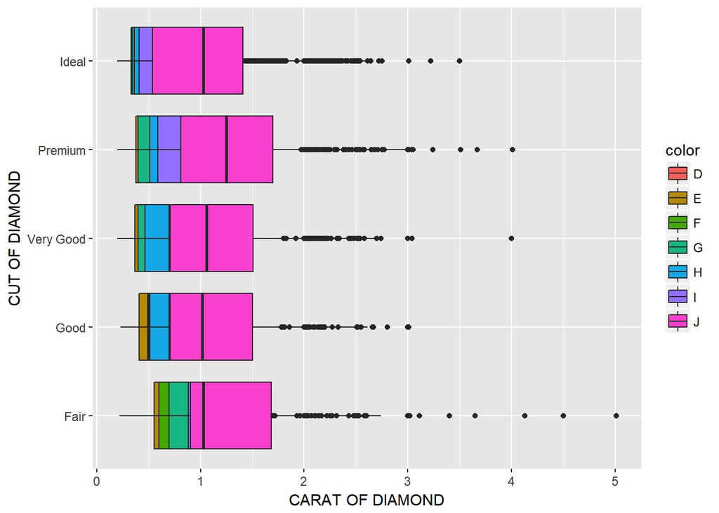

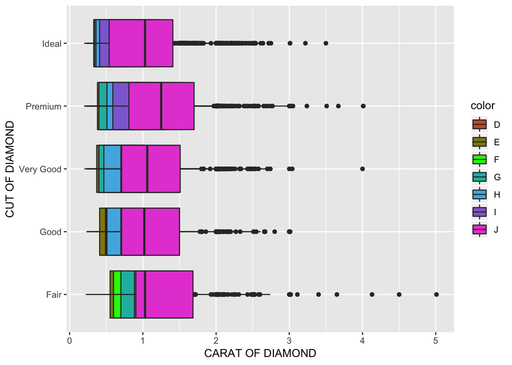

```r
ggplot(data = diamonds, mapping = aes(x = cut, y = carat, fill = color)) +
  geom_boxplot(position = 'identity') +
  labs(x ="CUT OF DIAMOND", y ="CARAT OF DIAMOND") +
  coord_flip() +
  scale_fill_manual(values=c("#cc5b39", "#918612", "green", "#1bbaac", "#52b4e5", "#8f6dd6", "#e54ed6"))
```

*3. The previous graphic is not very useful. We can make it much more useful by changing one thing about it. Make the change and plot it again.*

By changing the position from `'identity'` to `'dodge'`, the color group is more distinct and not crowded.

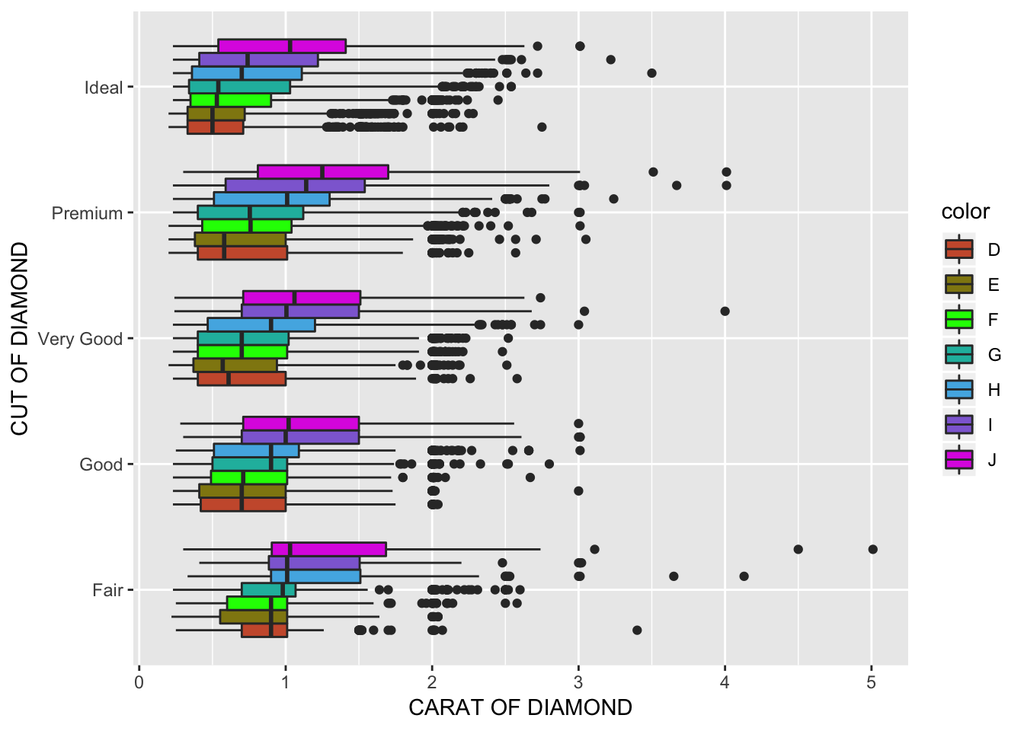

```r
ggplot(data = diamonds, mapping = aes(x = cut, y = carat, fill = color)) +
  geom_boxplot(position = 'dodge') +
  labs(x ="CUT OF DIAMOND", y ="CARAT OF DIAMOND") +
  coord_flip() +
  scale_fill_manual(values=c("#cc5b39", "#918612", "green", "#1bbaac", "#52b4e5", "#8f6dd6", "#dd38e2"))
```

# 5 Data munging and wrangling

*1. Is this data “tidy”?*

No, the data was not tidy because it needed spreading because there were two variables in `type`. The `spread()` function was used.

```r
(table2)
```

```
## # A tibble: 12 x 4
##    country      year type            count
##    <chr>       <int> <chr>           <int>
##  1 Afghanistan  1999 cases             745
##  2 Afghanistan  1999 population   19987071
##  3 Afghanistan  2000 cases            2666
##  4 Afghanistan  2000 population   20595360
##  5 Brazil       1999 cases           37737
##  6 Brazil       1999 population  172006362
##  7 Brazil       2000 cases           80488
##  8 Brazil       2000 population  174504898
##  9 China        1999 cases          212258
## 10 China        1999 population 1272915272
## 11 China        2000 cases          213766
## 12 China        2000 population 1280428583
```

```r
table2 %>%
  spread(key = type, value = count)
```

```
## # A tibble: 6 x 4
##   country      year  cases population
##   <chr>       <int>  <int>      <int>
## 1 Afghanistan  1999    745   19987071
## 2 Afghanistan  2000   2666   20595360
## 3 Brazil       1999  37737  172006362
## 4 Brazil       2000  80488  174504898
## 5 China        1999 212258 1272915272
## 6 China        2000 213766 1280428583
```

*2. Create a new column in the diamonds data set called price_per_carat that shows the price of each diamond per carat (hint: divide). Only show me the code, not the output.*

`diamonds %>% mutate(price_per_carat = price/carat)`

*3. For each cut of diamond in the diamonds data set, how many diamonds, and what proportion, have a price > 10000 and a carat < 1.5? There are several ways to get to an answer, but your solution must use the data wrangling verbs from the tidyverse in order to get credit. Do the results make sense? Why? Do we need to be wary of any of these numbers? Why?*

834 diamonds (1.5% from the total amount of diamonds) have a price > 10000 and a carat < 1.5. Diamonds that have a carat of 1.0 - 1.3 have about the same price. If one assumes that the most important factor for price is carat, than this data seems suspect. Because of this plateau in the data, more information on the diamonds in this particular region would be needed such as color, cut, etc.

```r
(filter(diamonds, price > 10000 & carat < 1.5)) %>%
   count()
```

```
## # A tibble: 1 x 1
##       n
##   <int>
## 1   834
```

```r
n.spec.diamonds <- filter(diamonds, price > 10000 & carat < 1.5) %>%
   count()

(n.spec.diamonds/count(diamonds) *100)
```

```
##          n
## 1 1.546162
```

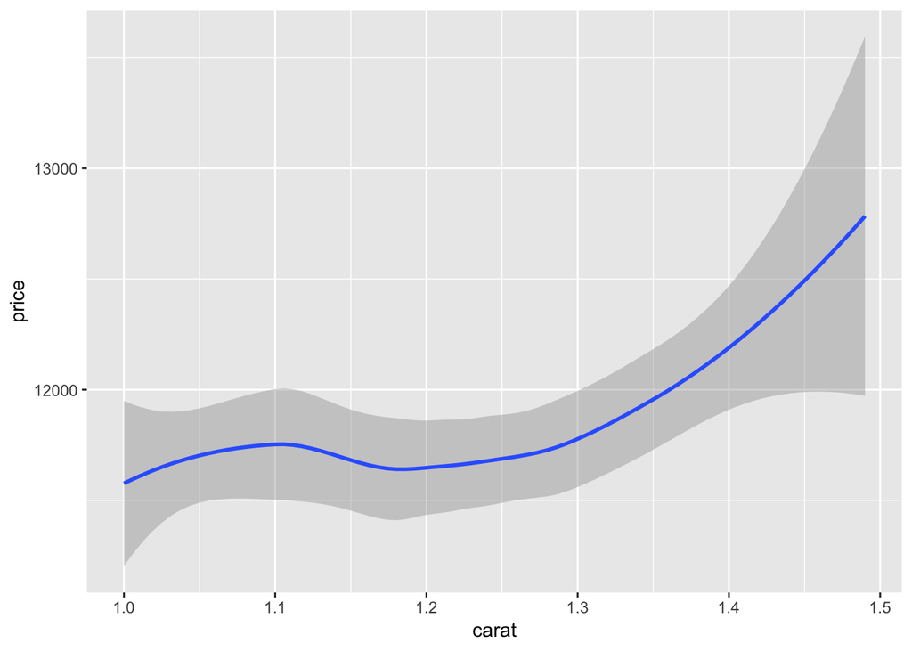

```r
spec.diamonds <- (filter(diamonds, price > 10000 & carat < 1.5))

top.diam <- select(spec.diamonds, price, carat) %>%
  filter(price > 10000)

ggplot(top.diam, aes(carat, price)) +
  geom_smooth()
```

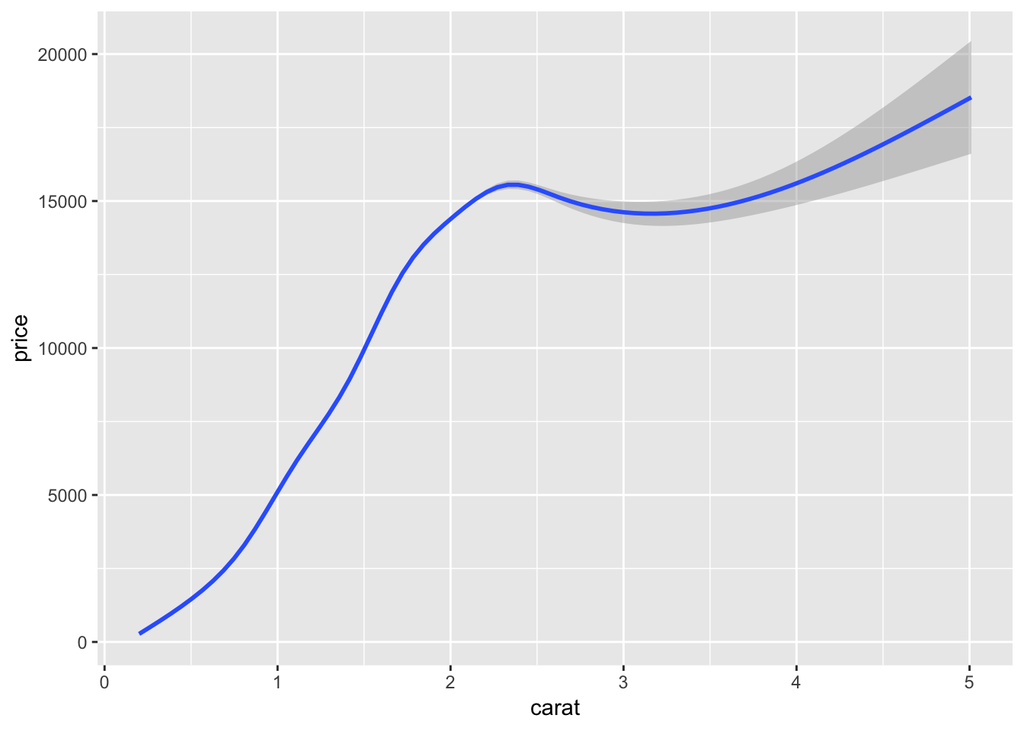

```r
ggplot(diamonds, aes(carat, price)) +
  geom_smooth()
```

# 6 EDA

*1. During what time period is this data from?*

The data is for the years of 2000-2015.

```r
?txhousing
distinct(txhousing, year)
```

```
## # A tibble: 16 x 1
##     year
##    <int>
##  1  2000
##  2  2001
##  3  2002
##  4  2003
##  5  2004
##  6  2005
##  7  2006
##  8  2007
##  9  2008
## 10  2009
## 11  2010
## 12  2011
## 13  2012
## 14  2013
## 15  2014
## 16  2015
```

*2. How many cities are represented?*

46 “cities” are represented.

```r
distinct(txhousing, city)
```

```
## # A tibble: 46 x 1
##    city
##    <chr>
##  1 Abilene
##  2 Amarillo
##  3 Arlington
##  4 Austin
##  5 Bay Area
##  6 Beaumont
##  7 Brazoria County
##  8 Brownsville
##  9 Bryan-College Station
## 10 Collin County
## # … with 36 more rows
```

*3. Which city, month and year had the highest number of sales?*

Houston had the highest number of sales with 1,043,999

June had the highest number of sales.

2006 had the highest number of sales.

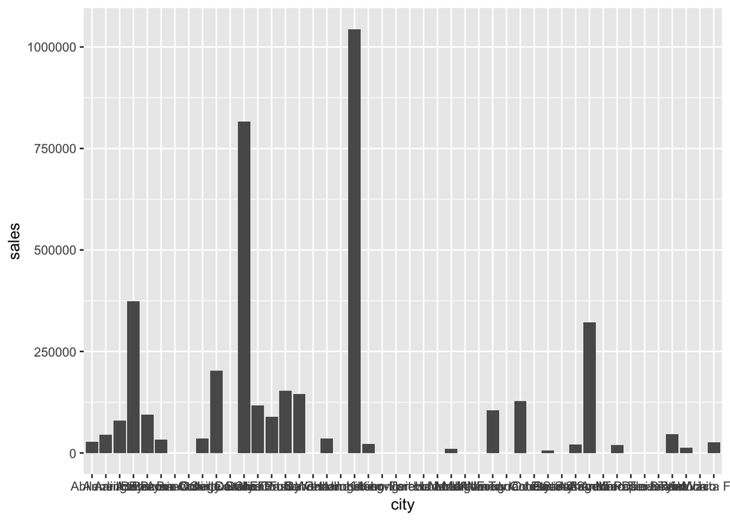

```r
sales.per.city <- arrange(txhousing, city, sales) %>%
  group_by(city) %>%
  summarise(sales = sum(sales))
ggplot(sales.per.city, aes(city, sales))+
  geom_col()
```

```r
arrange(sales.per.city, desc(sales))
```

```
## # A tibble: 46 x 2
##    city                sales
##    <chr>               <dbl>
##  1 Houston           1043999
##  2 Dallas             816122
##  3 Austin             373381
##  4 San Antonio        322097
##  5 Collin County      202892
##  6 Fort Bend          153088
##  7 Fort Worth         144791
##  8 NE Tarrant County  128007
##  9 Denton County      117405
## 10 Montgomery County  104589
## # … with 36 more rows
```

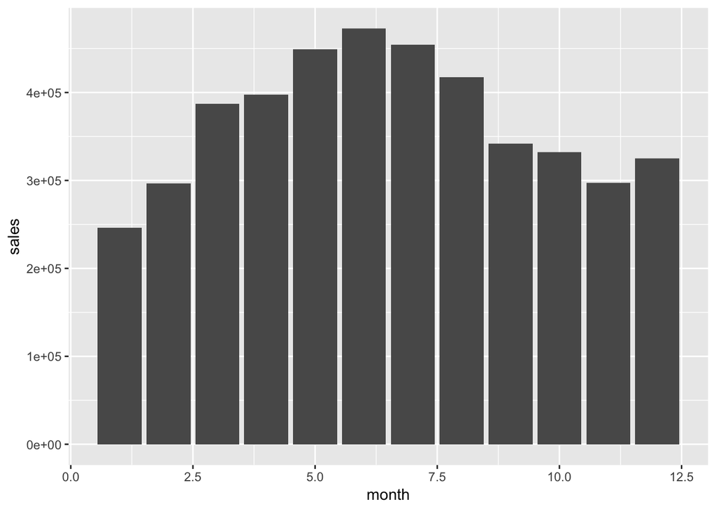

```r
ggplot(txhousing, aes(month, sales)) +
  geom_col()
```

```r
select(txhousing, year, sales) %>%
  group_by(year) %>%
  summarise(sales.per.year = sum(sales, na.rm = TRUE)) %>%
  arrange(desc(sales.per.year))
```

```
## # A tibble: 16 x 2
##     year sales.per.year
##    <int>          <dbl>
##  1  2006         347733
##  2  2014         345720
##  3  2013         335094
##  4  2007         327701
##  5  2005         316046
##  6  2012         287052
##  7  2004         283999
##  8  2008         276664
##  9  2009         255254
## 10  2003         253909
## 11  2011         246356
## 12  2010         243014
## 13  2002         234600
## 14  2001         231453
## 15  2000         222483
## 16  2015         208124
```

*4. What kind of relationship do you think exists between the number of listings and the number of sales? Check your assumption and show your work.*

The assumption is that there would be more sales given more listings but would taper off a certain level given the economics of supply and demand. Using `geom_smooth`, one can see that there is a strong positive correlation between sales and listings but slows down as the listings increase over 20000.

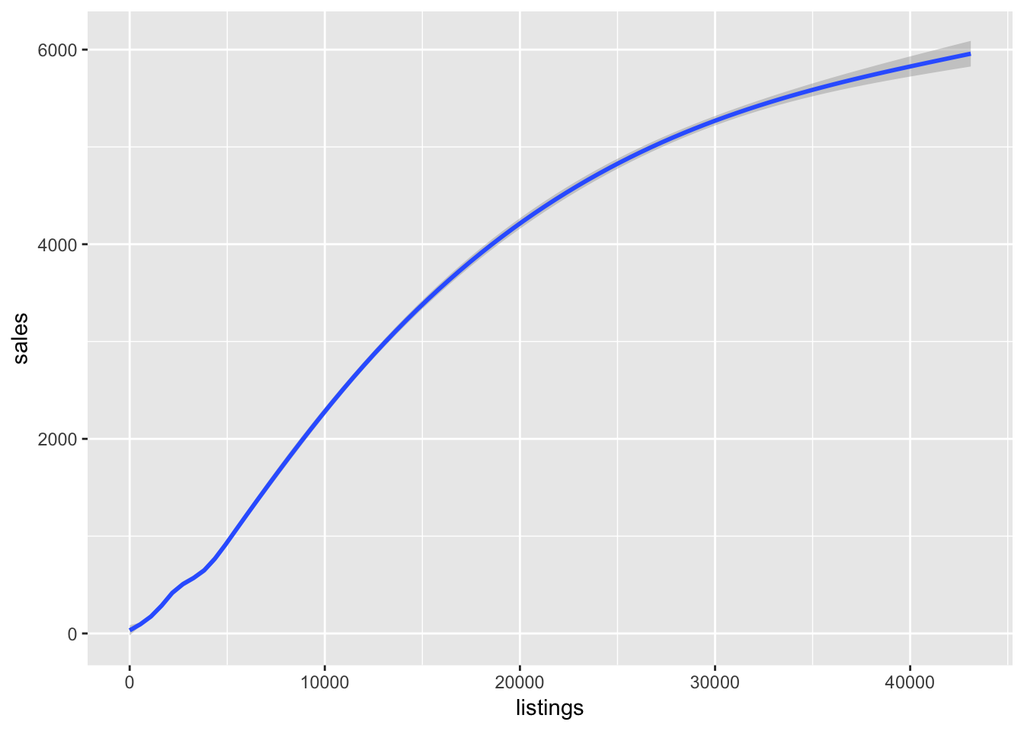

```r
ggplot(txhousing, aes(listings, sales)) +
  geom_smooth()
```

*5. What proportion of sales is missing for each city?*

```r
(missing.sales <- txhousing %>%
  filter(is.na(city)))
```

```
## # A tibble: 0 x 9
## # … with 9 variables: city <chr>, year <int>, month <int>, sales <dbl>,
## #   volume <dbl>, median <dbl>, listings <dbl>, inventory <dbl>,
## #   date <dbl>
```

```r
(not.missing.sales <- txhousing %>%
  filter(!is.na(city)))
```

```
## # A tibble: 8,602 x 9
##    city     year month sales   volume median listings inventory  date
##    <chr>   <int> <int> <dbl>    <dbl>  <dbl>    <dbl>     <dbl> <dbl>
##  1 Abilene  2000     1    72  5380000  71400      701       6.3 2000
##  2 Abilene  2000     2    98  6505000  58700      746       6.6 2000.
##  3 Abilene  2000     3   130  9285000  58100      784       6.8 2000.
##  4 Abilene  2000     4    98  9730000  68600      785       6.9 2000.
##  5 Abilene  2000     5   141 10590000  67300      794       6.8 2000.
##  6 Abilene  2000     6   156 13910000  66900      780       6.6 2000.
##  7 Abilene  2000     7   152 12635000  73500      742       6.2 2000.
##  8 Abilene  2000     8   131 10710000  75000      765       6.4 2001.
##  9 Abilene  2000     9   104  7615000  64500      771       6.5 2001.
## 10 Abilene  2000    10   101  7040000  59300      764       6.6 2001.
## # … with 8,592 more rows
```

```r
(not.missing.listings <- txhousing %>%
  filter(!is.na(listings)))
```

```
## # A tibble: 7,178 x 9
##    city     year month sales   volume median listings inventory  date
##    <chr>   <int> <int> <dbl>    <dbl>  <dbl>    <dbl>     <dbl> <dbl>
##  1 Abilene  2000     1    72  5380000  71400      701       6.3 2000
##  2 Abilene  2000     2    98  6505000  58700      746       6.6 2000.
##  3 Abilene  2000     3   130  9285000  58100      784       6.8 2000.
##  4 Abilene  2000     4    98  9730000  68600      785       6.9 2000.
##  5 Abilene  2000     5   141 10590000  67300      794       6.8 2000.
##  6 Abilene  2000     6   156 13910000  66900      780       6.6 2000.
##  7 Abilene  2000     7   152 12635000  73500      742       6.2 2000.
##  8 Abilene  2000     8   131 10710000  75000      765       6.4 2001.
##  9 Abilene  2000     9   104  7615000  64500      771       6.5 2001.
## 10 Abilene  2000    10   101  7040000  59300      764       6.6 2001.
## # … with 7,168 more rows
```

```r
(txhousing %>%
  select(city, sales, month, year) %>%
  arrange(!desc(sales))) %>%
  filter(sales < 9)
```

```
## # A tibble: 1 x 4
##   city       sales month  year
##   <chr>      <dbl> <int> <int>
## 1 San Marcos     6    10  2011
```

*6. Looking at only the cities and months with greater than 500 sales: Are the distributions of the median sales price (column name median), when grouped by city, different? The same? Show your work. Any cities that stand out that you’d want to investigate further? Why might we want to filter out all cities and months with sales less than 500?*

The distributions of the median sales price when grouped by city and month are different. There is more variation when looking at city. The data is more homogenous for months. Collin County has the highest median sale price which is interesting as, per wikipedia, only has a population of less than 800,000 people. Having a filter of more than 500 sales ensures a large enough sample size so that outliers don’t affect the average median sale price.

```r
(five.hundred <- txhousing %>%
  filter(sales > 500))
```

```
## # A tibble: 1,883 x 9
##    city       year month sales   volume median listings inventory  date
##    <chr>     <int> <int> <dbl>    <dbl>  <dbl>    <dbl>     <dbl> <dbl>
##  1 Arlington  2000     8   507 60875199 103400     1417       3.5 2001.
##  2 Arlington  2001     5   536 69878959 114400     1592       3.7 2001.
##  3 Arlington  2001     6   534 67744182 108500     1627       3.8 2001.
##  4 Arlington  2001     8   505 65080743 113600     1616       3.7 2002.
##  5 Arlington  2002     5   503 67240236 116100     1741       3.9 2002.
##  6 Arlington  2002     7   509 66954143 119100     1925       4.4 2002.
##  7 Arlington  2003     5   502 67131982 118000     2544       5.9 2003.
##  8 Arlington  2003     7   524 73194692 123500     2799       6.5 2004.
##  9 Arlington  2003     8   531 72397143 123900     2801       6.4 2004.
## 10 Arlington  2004     5   527 72401436 118300     2922       6.5 2004.
## # … with 1,873 more rows
```

```r
(city.500 <- five.hundred %>%
  group_by(city) %>%
  summarise(median = mean(median)) %>%
  arrange(desc(median)))
```

```
## # A tibble: 14 x 2
##    city               median
##    <chr>               <dbl>
##  1 Collin County     201890.
##  2 Montgomery County 185814.
##  3 Fort Bend         185634.
##  4 Austin            181998.
##  5 Denton County     168869.
##  6 NE Tarrant County 165682.
##  7 Dallas            160783.
##  8 Bay Area          156586.
##  9 Houston           149780.
## 10 San Antonio       138470.
## 11 Arlington         133451.
## 12 Corpus Christi    130720
## 13 El Paso           123958.
## 14 Fort Worth        114231.
```

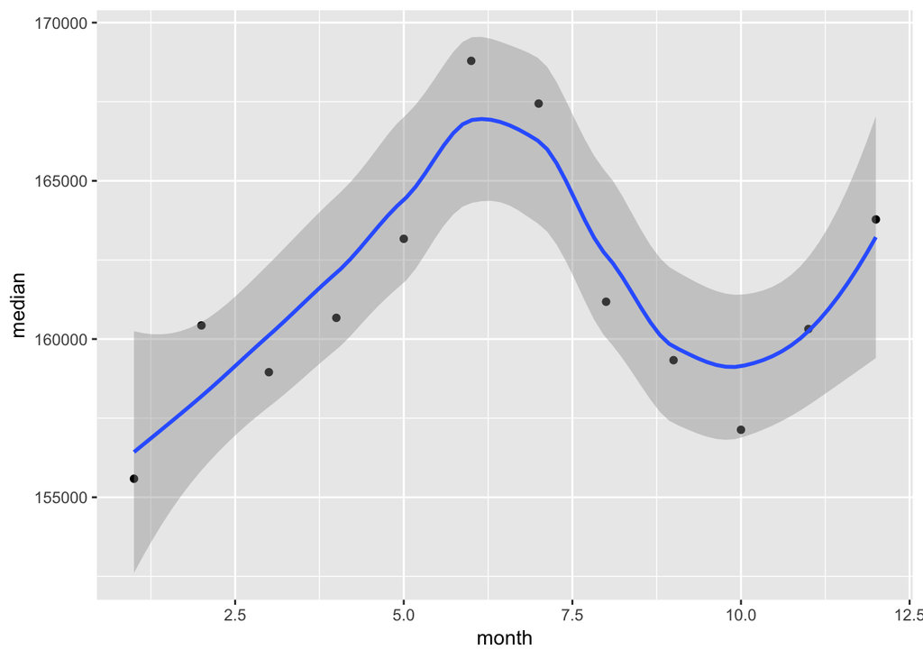

```r
month.500 <- five.hundred %>%
  group_by(month) %>%
  summarise(median = mean(median))

ggplot(month.500, aes(month, median)) +
  geom_point() +
  geom_smooth()
```

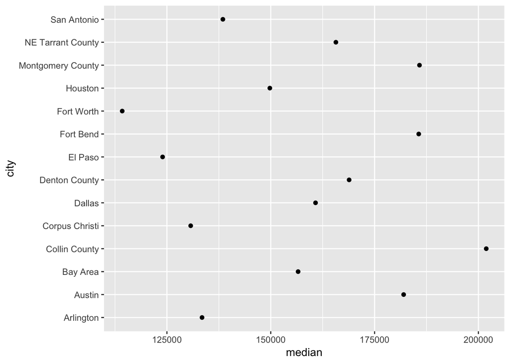

```r
ggplot(city.500, aes(city, median)) +
  geom_point() +
  geom_smooth() +
  coord_flip()
```